# EDAVFinalProject

### Fall 2018 EDAV Final Project

# The Global Refugee Crisis

#### *Github link to Project*

https://github.com/nanshanli/edavfp-refugees

## 1. Introduction

Our project is on the Global Refugee Crisis, with a primary focus on the 5 major current refugee events in Afghanistan, the Democratic Republic of Congo, Myanmar, South Sudan and the Syrian Arab Republic.

### 1.1 Why we chose this topic

We decided to embark on this project for several reasons. The primary reason is that the global refugee crisis is the major humanitarian crisis of our times: the refugee population increased by almost 3 million from 2016 to 2017 alone. Adding to this problem is the unfriendly political climate surrounding refugee inflows, especially with the rise of right-wing nationalism in the Western world. Most countries simply adopt a “not in my backyard” mentality as these crises occur far away from them and their occurrence does not threaten the stability and peace in their region.

We also often read of terrible, inhumane conditions in refugee camps and boats of refugees that survived the treacherous journey through the Mediterranean Sea being turned back and denied their legal right to assistance. Thus, in this project, we wanted to look at data that described and would hopefully shed more light on this crisis.

### 1.2 Questions we were interested in studying:

- Where are refugees mostly originating from and what kind of events occurred to make them leave?
- What are the historical events that led to this current outflow?
- Which are the countries taking in the most refugees, and why?
- Are refugee outflows equitably distributed in the world?
- Why are some other countries not taking in refugees?
- Which demographic segment of the population are affected by these crisis?

### 1.3 Group members and distribution of work

We split the data cleaning evenly, each taking 2 csv files for cleaning and the initial exploratory data analysis. After that, we decided on the events and subsets to focus on for our project collectively. We also split the components of the reports and presentations equally.

The data visualization component was divided as following:

- Megala Kannan: Interactive line chart
- Nanshan Li: Alluvial diagram and demographic bar charts
- Pranav Alva: Generating choroplethR maps and combining the maps into our interactive component.

## 2 Description of data

The data for this project was collected from the [Office of the United Nations High Commissioner of Refugees (UNHCR)](http://popstats.unhcr.org). The database currently contains data about UNHCR’s populations of concern from the year 1951 up to 2017. The population of concern includes the following 6 categories: Refugees, Asylum Seekers, Internally displaced persons, returned refugees, returned IDPs, stateless persons and others of concern. This data was used to investigate different aspects of these populations: their general composition by location of residence or origin, their status (refugees, asylum seekers, internally displaced persons, etc.), their numbers over time, and so on.

The data was collected in the form of 6 files (.csv) by selecting the subset of data we were interested in. All data was collected for the years 1951 to 2017. This includes: 1. Persons of concern: UNHCR’s populations of concern for a given year and country of residence and/or origin. 2. Time series: The total persons of concerns data represented as a time series. 3. Demographics: Information about persons of concern broken down by sex and age, as well as by location within the country of residence 4. Asylum seekers (Refugee status determination): Information about asylum applications in a given year and the progress of asylum-seekers through the refugee status determination process. 5. Asylum seekers (monthly data): Asylum seekers data broken down by month and origin. 6. Resettlement: Information on resettlement arrivals of refugees, with or without UNHCR assistance.

## 3 Data quality

The data only included values up to mid-2017, and hence is not complete for the year 2017. Additionally, there were many fields that were filled with asterisks. According to the metadata from UNCHR, these represent situations in which figures are being kept confidential to protect the anonymiy of individuals. An example of the asterisks in the data can be seen below. There were also fields in which no figures were available. We coded all these values to 0. We also needed to rename the columns in order to work on the data in several of our csv files.

```r
un <- read.csv('./Data/unhcr_popstats_export_asylum_seekers_all_data.csv', skip = 3, header = TRUE)
tail(un)
```

```
##        Year Country...territory.of.asylum.residence   Origin
## 140826 2017                                Bulgaria Zimbabwe
## 140827 2017                                 Belgium Zimbabwe
## 140828 2017                                 Austria Zimbabwe
## 140829 2017                               Australia Zimbabwe
## 140830 2017                               Australia Zimbabwe
## 140831 2017                                  Angola Zimbabwe
##        RSD.procedure.type...level Tota.pending.start.year
## 140826                     G / FI
## 140827                     G / FI
## 140828                     G / FA                       6
## 140829                     G / AR                      29
## 140830                     G / FI                      82
## 140831                     G / FI                       *
##        of.which.UNHCR.assisted Applied.during.year
## 140826                                           *
## 140827                                           5
## 140828                                           *
## 140829                       0                  30
## 140830                       0                  51
## 140831
##        statistics.filter.decisions_recognized
## 140826
## 140827
## 140828
## 140829                                      8
## 140830                                      9
## 140831
##        statistics.filter.decisions_other Rejected Otherwise.closed
## 140826
## 140827                                          5
## 140828
## 140829                                 0        9                *
## 140830                                 0       45
## 140831
##        Total.decisions Total.pending.end.year of.which.UNHCR.assisted.1
## 140826
## 140827               5                      5
## 140828                                      5
## 140829              21                     38                         0
## 140830              54                     79                         0
## 140831                                      *                         0
```

This was the main dataframe on which most of our visualizations were based on. The data has 5 variables.

```r
timeseries <- read.csv('./Data/unhcr_popstats_export_time_series_all_data.csv', skip = 3, header = TRUE)
tail(timeseries)
```

```
##        Year Country...territory.of.asylum.residence   Origin
## 180678 2017                                Zimbabwe   Uganda
## 180679 2017                                Zimbabwe   Uganda
## 180680 2017                                Zimbabwe   Uganda
## 180681 2017                                Zimbabwe   Zambia
## 180682 2017                                Zimbabwe Zimbabwe
## 180683 2017                                Zimbabwe Zimbabwe
##                                 Population.type Value
## 180678 Refugees (incl. refugee-like situations)     8
## 180679                           Asylum-seekers     *
## 180680                        Others of concern     *
## 180681                        Others of concern     4
## 180682                        Returned refugees    38
## 180683                        Others of concern   137
```

Another dataframe on which a part of our visualizations were on was the demographic data collected by UNHCR from 2001-2017. For the demographic data, the organization collected the population numbers of those aged 5-17 in a single category before 2011, and as two categories (5-11 and 12-17) from 2011 and after. Within countries, the demographic data is further split into more specific location names, although the data collection was not consistent and many location names only appear once in the entire dataframe.

```r
dem <- read.csv('./Data/unhcr_popstats_export_demographics_all_data.csv', skip = 3, header = TRUE)
tail(dem)
```

```
##       Year Country...territory.of.asylum.residence
## 18533 2017                                  Zambia
## 18534 2017                                  Zambia
## 18535 2017                                  Zambia
## 18536 2017                                  Zambia
## 18537 2017                                Zimbabwe
## 18538 2017                                Zimbabwe
##                                       Location.Name Female.0.4 Female.5.11
## 18533                          Mayukwayukwa : Point        972        1255
## 18534                                Meheba : Point       1475        2238
## 18535                                     Nchelenge       1420        1553
## 18536 Zambia : Dispersed in the country / territory        637        1444
## 18537                         Manicaland : Province        740        1171
## 18538                                 Harare : City        242         120
##       Female.5.17 Female.12.17 Female.18.59 Female.60. F..Unknown F..Total
```

[output cut: 20 more lines]

There are 18538 rows in the dataframe, and 6223 unique location names.

```r
length(unique(dem$Location.Name))
```

```
## [1] 6223
```

# 4 Main Analysis (Exploratory Data Analysis)

## 4.1 Initial Exploration

We started out by exploring the different datasets on our own through Q3 in Homework 4. The 3 datasets we explored were time series (Pranav), asylum seekers (Megala) and resettlement data (Nanshan).

### 4.1.1 Time series

The following shows a plot of the overall population of persons of concern. There are almost 50 million of them in 2016, with a dip in 2017 due to the fact that the data only goes up to mid-2017.

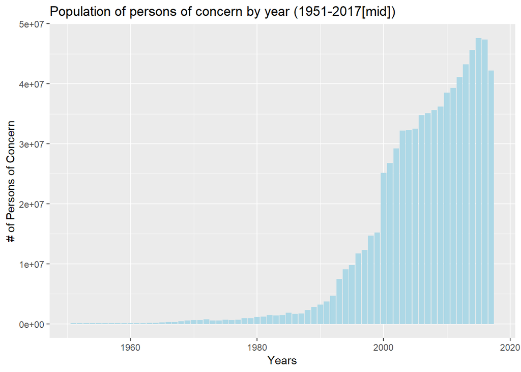

```r
# Filtering out the rows for which the populations are confidential
timeseries <- timeseries %>% filter(Value != "*")
timeseries$Value <- as.numeric(timeseries$Value)

g2<-ggplot(timeseries, aes(x = Year, y = Value)) + geom_col(fill='lightblue') +
    ggtitle("Population of persons of concern by year (1951-2017[mid])") +
  xlab("Years") +
  ylab("# of Persons of Concern")
g2
```

A cleveland dot plot of the countries with the largest refugee populations in 2016 was plotted, showing that the countries were Canada, USA, Germany, United Kingdom, Sweden and so on.

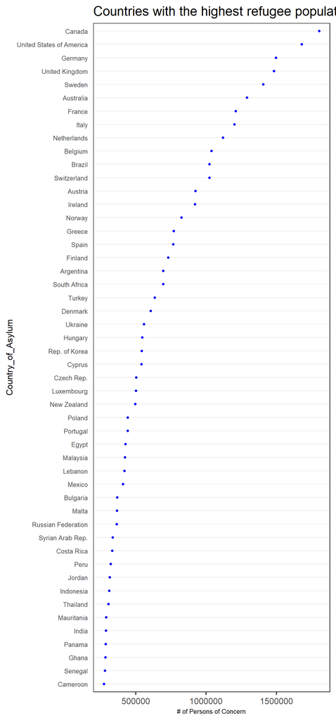

```r
colnames(timeseries)[colnames(timeseries) ==
                     "Country...territory.of.asylum.residence"] <- "Country_of_Asylum"


theme_dotplot <- theme_bw(18) +
    theme(axis.text.y = element_text(size = rel(.75)),
          axis.ticks.y = element_blank(),
          axis.title.x = element_text(size = rel(.75)),
          panel.grid.major.x = element_blank(),
          panel.grid.major.y = element_line(size = 0.5),
          panel.grid.minor.x = element_blank())

timeseries2 <- timeseries %>%
  group_by(Country_of_Asylum) %>%
  filter(Year == "2016") %>%
  summarize(Value=sum(Value)) %>%
  arrange(desc(Value)) %>%
  head(n=50)

cplot<-ggplot(timeseries2, aes(x = Value, y = fct_reorder(Country_of_Asylum, Value))) +
    geom_point(color = "blue") +
  ylab("Country_of_Asylum") +
  xlab("# of Persons of Concern") +
  theme_dotplot + theme(axis.text=element_text(size=13),
                         axis.title=element_text(size=13)) +
  ggtitle("Countries with the highest refugee populations in 2016") +
  theme(plot.title = element_text(size = 20))
cplot
```

From the chart below, the top 50 countries from which persons of concern originate from in 2016 are Syria, Dem Rep. of the Congo, Somalia, Iraq and Afghanistan.

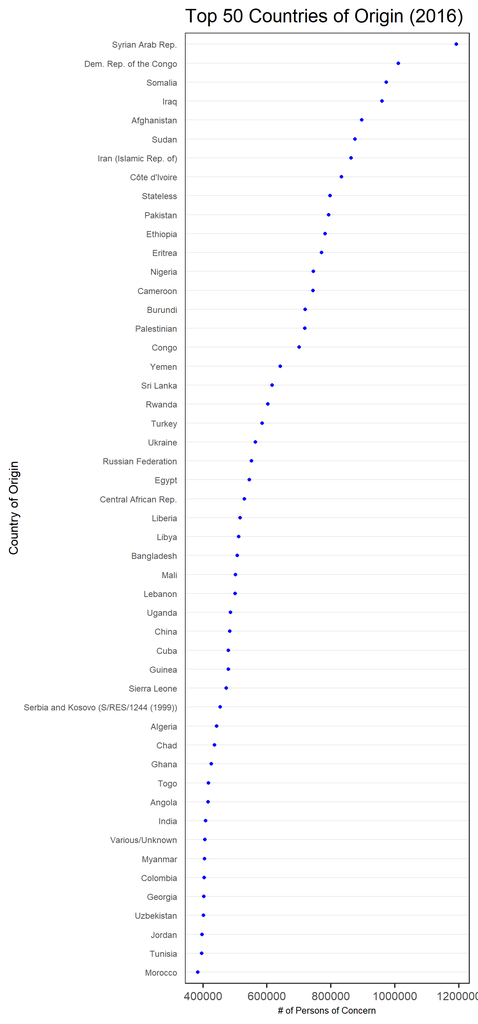

```r
timeseries3 <- timeseries %>%
  group_by(Origin) %>%
  filter(Year == 2016) %>%
  summarize(Value=sum(Value)) %>%
  arrange(desc(Value)) %>%
  head(n=50)

cplot<-ggplot(timeseries3, aes(x = Value, y = fct_reorder(Origin, Value))) +
    geom_point(color = "blue") +
  ylab("Country of Origin") +
  xlab("# of Persons of Concern") +
  theme_dotplot +
  theme(axis.text=element_text(size=12),
                         axis.title=element_text(size=13)) +
  ggtitle("Top 50 Countries of Origin (2016)") +
  theme(plot.title = element_text(size = 20))
cplot
```

### 4.1.2 Asylum seekers data

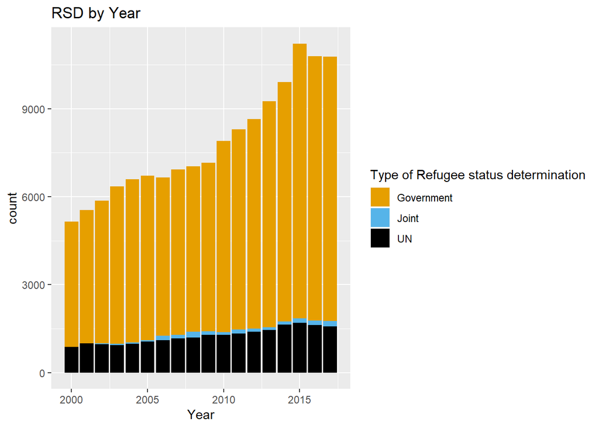

```r
# fill missing values to 0
un[is.na(un)] <- 0
#View(un)
split <- un %>% separate(RSD.procedure.type...level, c("type", "level"))
un <- un %>% mutate(type = split$type) %>% mutate( level = split$level)
ggplot(un, aes(x= Year)) +
      geom_bar(aes(fill = factor(type))) +
      scale_fill_manual(values=c("#999999", "#E69F00", "#56B4E9", "black"),
                       name="Type of Refugee status determination",
                       breaks=c("G", "J", "U"),
                       labels=c("Government", "Joint", "UN")) +
      ggtitle("RSD by Year")
```

The following Cleveland dot plot shows the number of refugees from different origin countries accorded different statuses by either the government or the UN. Similar countries with the highest number of refugees seeking asylum are observed, and there are proportionately more asylum seekers being awarded their status by governments rather than the UN.

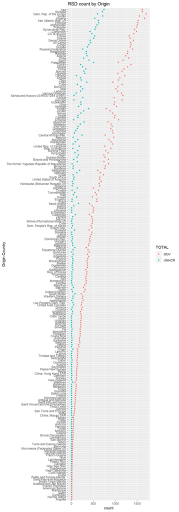

```r
un_plot <- un %>% group_by(Origin) %>% summarize(UNHCR= sum(type == "U"), GOV= sum(type=="G"))
#View(un_plot)
new_un <- un_plot %>% gather(key="TOTAL", value="type", -Origin)
#View(new_un)
ggplot(new_un, aes(x= type, y= reorder(Origin,type) , color= TOTAL)) +
      geom_point() + ylab("Origin Country") + xlab("count") +
      ggtitle("RSD count by Origin")
```

### 4.1.3 Resettlement Data

The last dataset that we looked at for the initial exploratory stage was resettlment of refugees, either back to their origin country or to a different asylum country.

```r
resettlement <- read.csv('./Data/unhcr_popstats_export_resettlement_all_data.csv', header = TRUE, skip = 3)

colnames(resettlement)[colnames(resettlement) ==
                         "Country...territory.of.asylum.residence"] <- "Country_of_asylum"

resettlement <- resettlement %>% filter(Value != "*")
resettlement$Value <- as.numeric(resettlement$Value)

resettlement_bycountry <- resettlement %>%
  group_by(Country_of_asylum, Year) %>%
  summarise(Value = sum(Value)) %>%
  filter(Year == 2016) %>%
  arrange(desc(Value))

resettlement_bycountry
```

```
## # A tibble: 30 x 3
## # Groups:   Country_of_asylum [30]
##    Country_of_asylum         Year Value
##    <fct>                    <int> <dbl>
##  1 Australia                 2016 84720
##  2 United States of America  2016 51996
##  3 Canada                    2016 39924
##  4 New Zealand               2016 25488
##  5 Sweden                    2016 18694
##  6 France                    2016  9626
##  7 Norway                    2016  9463
##  8 Denmark                   2016  8961
##  9 Netherlands               2016  6171
## 10 Finland                   2016  4893
## # ... with 20 more rows
```

The top 5 countries from this list were noted down and saved to an array, and used to subset the data so that the time series for this special subset of refugees can be plotted in a line chart

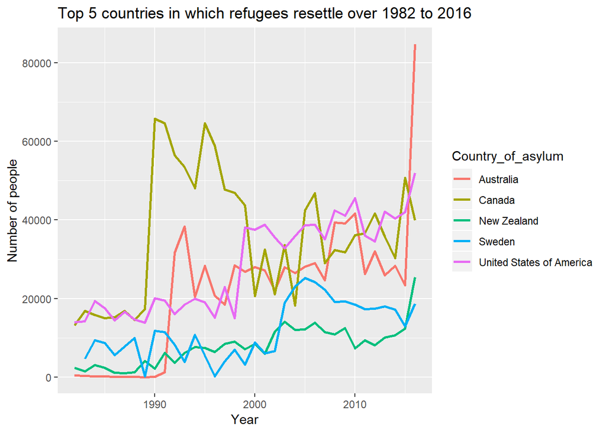

```r
topcountries <- c("Australia", "United States of America", "Canada",
                  "New Zealand", "Sweden")

resettlement_bycountry <- resettlement %>%
  group_by(Country_of_asylum, Year) %>%
  summarise(Value = sum(Value))

resettlement_bycountry_subset <- resettlement_bycountry %>%
  filter(Country_of_asylum %in% topcountries)

ggplot(resettlement_bycountry_subset, aes(x = Year, y = Value, col = Country_of_asylum)) +
  geom_line(size = 1) +
  scale_x_continuous(limits=c(1982,2016)) +
  ggtitle('Top 5 countries in which refugees resettle over 1982 to 2016') +
  ylab('Number of people')
```

```r
resettlement_byorigin <- resettlement %>%
  group_by(Origin, Year) %>%
  summarise(Value = sum(Value))

resettlement_byorigin_subset <- resettlement_byorigin %>%
  group_by(Origin) %>%
  filter(Year == 2016) %>%
  summarise(Value = sum(Value)) %>%
  arrange(desc(Value))

resettlement_byorigin_subset
```

```
## # A tibble: 149 x 2
##    Origin                 Value
##    <fct>                  <dbl>
##  1 Syrian Arab Rep.       18120
##  2 Eritrea                 7715
##  3 Iraq                    6783
##  4 Dem. Rep. of the Congo  6632
##  5 South Sudan             5887
##  6 Somalia                 5672
##  7 Burundi                 5670
##  8 Ethiopia                5635
##  9 Sudan                   5624
## 10 Central African Rep.    5215
## # ... with 139 more rows
```

The graph below allows us to visualize the trends in the origin country of resettling refugees over the years.

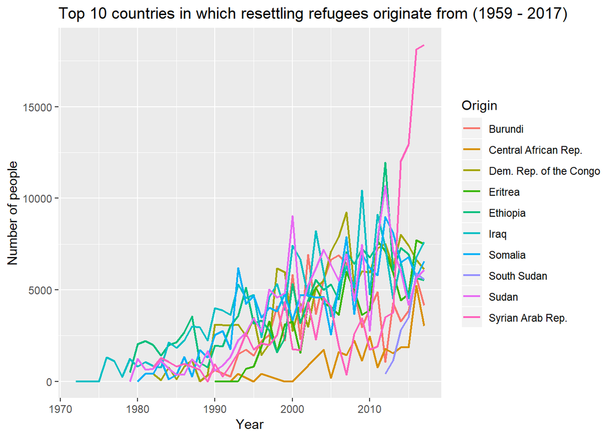

```r
top10countries <- c("Syrian Arab Rep.", "Eritrea", "Iraq", "Dem. Rep. of the Congo", "South Sudan", "Somalia", "Burundi", "Ethiopia", "Sudan", "Central African Rep.")

resettlement_byorigin_subset <- resettlement_byorigin %>%
  filter(Origin %in% top10countries)

ggplot(resettlement_byorigin_subset, aes(x = Year, y = Value, col = Origin)) +
  geom_line(size = 0.8) +
  ggtitle('Top 10 countries in which resettling refugees originate from (1959 - 2017)') +
  ylab('Number of people')
```

## 4.2 Subsetting data for further analysis

Upon looking at the results from our initial exploration, we realized that we had to to subset our data in order to obtain meaningful visualizations from it. There were simply too many possible permutations of origin and asylum country for there to be any conclusions drawn without retrieving a smaller subset of the data.

We did the subsetting using the time series data, as it was the most complete form of the persons of concern population in all 6 datasets. 5 current events were selected and used to base our further analysis on. We chose to include 3 population types: “Refugees”, “Asylum-seekers” (essentially with pending refugee status) and “Internally displaced persons”, as many people from countries with conflict are usually first internally displaced before deciding to head to a different country and becoming asylum seekers / refugees.

```r
# Where refugees are coming from
CrisesOriginCountries <- c("Syrian Arab Rep.", "South Sudan", "Afghanistan", "Dem. Rep. of the Congo", "Myanmar")

CrisesOriginRefugees <- timeseries %>%
  filter(Origin %in% CrisesOriginCountries) %>%
  filter(Population.type %in% c("Refugees (incl. refugee-like situations)","Asylum-seekers", "Internally displaced persons"))

#write.csv(CrisesOriginRefugees,'CrisesOrigin.csv')

# Where refugees are going now
LDRefugeeCountries <- c("Turkey", "Jordan", "Pakistan", "Lebanon","Iran", "Ethiopia", "Sudan", "Kenya", "Dem. Rep. of the Congo", "Chad", "Bangladesh")
MDRefugeeCountries <- c("Germany", "Sweden")
MediterranianCountries <- c("Greece", "Italy")

RefugeeCountries <- timeseries %>%
  filter(Country_of_Asylum %in% MediterranianCountries | Country_of_Asylum %in% LDRefugeeCountries | Country_of_Asylum %in% MDRefugeeCountries) %>%
  filter(Population.type %in% c("Refugees (incl. refugee-like situations)","Asylum-seekers")) #%>% # cannot add IDP to this list

#write.csv(RefugeeCountries,'RefugeePoplnInCountries.csv')
```

The countries were chosen both for their prominence in their regions as well as the volume of refugees from those countries. The 5 countries we decided to base the second phase of our project on were Syria, South Sudan, Afghanistan, Democratic Republic of Congo and Myanmar.

## 4.3 Final exploration and charts

### 4.3.1 Alluvial chart

In order to show the flow of refugees from their origin to destination countries, an alluvial diagram was plotted.

```r
library(ggalluvial)
library(RColorBrewer)

RefugeeCountries <- read.csv('./Data/Subsets/RefugeePoplnInCountries.csv', header = TRUE)

RefugeeCountries_filter <- RefugeeCountries %>%
  filter(Year == 2016) %>%
  filter(Origin %in% CrisesOriginCountries) %>%
  group_by(Origin, Country) %>%
  summarise(Value = sum(Value)) %>%
  filter(Value >= 5000)

colourCount = length(unique(RefugeeCountries_filter$Origin))
getPalette = colorRampPalette(brewer.pal(9, "Set1"))

ylab <- c(2.0, 4.0, 6.0, 8.0)
alluvial <- ggplot(RefugeeCountries_filter, aes(y = Value, axis1 = Origin, axis2 = Country)) +
  geom_alluvium(aes(fill = Origin), color = "black") +
  geom_stratum(width = 1/8)+
  geom_text(stat = "stratum", label.strata = TRUE, check_overlap = TRUE) +
  scale_x_discrete(limits = c("Origin", "Country"), expand = c(.05, .05)) +
  ylab('Population in 2016 (millions)') +
  ggtitle('Refugee population and origin in various countries, 2016') +
  scale_y_continuous(labels = ylab, breaks = 10^6 * ylab)
```

### 4.3.2 Demographic charts

To further our analysis, we also plotted charts on the demographic breakdown of persons of concerns from the 5 countries we were analyzing in this project.

```r
library(reshape)
library(gridExtra)
dem <- read_csv('./Data/UNHCR_Demographics.csv')
colnames(dem)[colnames(dem) ==
                     "Country / territory of asylum/residence"] <- "Country"

dem_long <- gather(dem,demographic,number,-Year, -'Country',-'Location Name')
dem_long <- dem_long %>%
  transform(dem = colsplit(demographic, split = "\\ ", names = c('sex', 'age')))

# Recoding confidential data points to 0
dem_long$number[is.na(dem_long$number)] <- 0
```

The demographic data was inconsistent in the method of data collection as well as the values. This was evident in 4 of the countries we looked at, with the exception of South Sudan.

We decided to plot absolute values, relative values (to visualize the changes in proportions over the years) and a variable width bar chart for an accurate representation of the actual distribution across ages and sex.

#### South Sudan

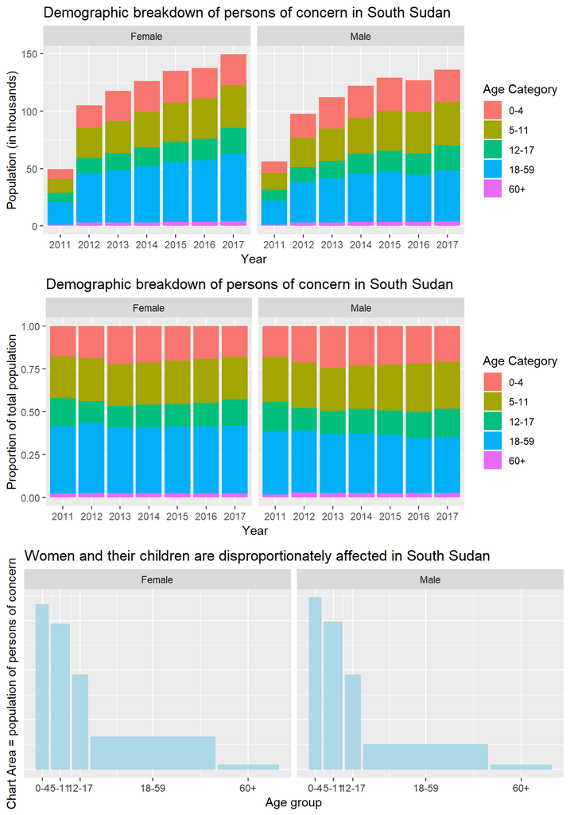

```r
# Cleaning for Sudan
dem_sudan <- dem_long %>%
  filter(Country == 'South Sudan') %>%
  filter(Year >= 2011 & Year <= 2017) %>%
  filter(dem.sex %in% c("Female","Male")) %>%
  group_by(Country, Year, dem.sex, dem.age) %>%
  summarise(number = sum(number))

# The age 5-17 category was not used in tracking persons of concern from South Sudan
dem_sudan<-dem_sudan[!(dem_sudan$dem.age =="5-17"),]

# Reordering the factor categories
dem_sudan$dem.age <- factor(dem_sudan$dem.age, levels = c("0-4", "5-11", "12-17", "18-59", "60+"))

# Demographic bar chart
sudan_stack <- ggplot(dem_sudan, aes(x = factor(Year), y = number / 1000)) +
  geom_bar(aes(fill = dem.age),stat = "identity", position = "stack") +
  facet_wrap(.~dem.sex) +
  xlab('Year') +
  ylab('Population (in thousands)') +
  ggtitle('Demographic breakdown of persons of concern in South Sudan') +
  scale_fill_discrete(name = "Age Category")

# Demographic bar chart
sudan_fill <- ggplot(dem_sudan, aes(x = factor(Year), y = number / 1000)) +
  geom_bar(aes(fill = dem.age),stat = "identity", position = "fill") +
  facet_wrap(.~dem.sex) +
  xlab('Year') +
  ylab('Proportion of total population') +
  ggtitle('Demographic breakdown of persons of concern in South Sudan') +
  scale_fill_discrete(name = "Age Category")

# Demographic variable width bar chart
dem_sudan_sum <- dem_sudan %>%
  filter(Year == 2016) %>%
  group_by(Country, Year, dem.age, dem.sex) %>%
  summarise(number = sum(number))

dem_sudan_sum$binwidth <- recode(dem_sudan_sum$dem.age, "0-4" = 4, "5-11" = 6, "12-17" = 5, "18-59" = 41, "60+" = 20)
dem_sudan_sum$center <- recode(dem_sudan_sum$dem.age, "0-4" = 2, "5-11" = 8, "12-17" = 14.5, "18-59" = 38.5, "60+" = 70)
dem_sudan_sum$breaks <- recode(dem_sudan_sum$dem.age, "0-4" = 4, "5-11" = 12, "12-17" = 17, "18-59" = 59, "60+" = 80)
cats <- c("0-4","0-4","5-11", "5-11","12-17","12-17", "18-59", "18-59", "60+", "60+")
total <- sum(dem_sudan_sum$number)
sudan_variable <- ggplot(dem_sudan_sum, aes(x = center, y = number / binwidth, width = binwidth)) +
  geom_col(color = "lightblue", fill = "lightblue") +
  scale_x_continuous(labels = cats, breaks = dem_sudan_sum$center) +
  facet_grid(.~dem.sex) +
  xlab('Age group') +
  ylab('Chart Area = population of persons of concern') +
  ggtitle('Women and their children are disproportionately affected in South Sudan') +
  theme(#axis.title.y=element_blank(),
        axis.text.y=element_blank(),
        axis.ticks.y=element_blank())

grid.arrange(sudan_stack, sudan_fill, sudan_variable)
```

#### Syria Arab Republic

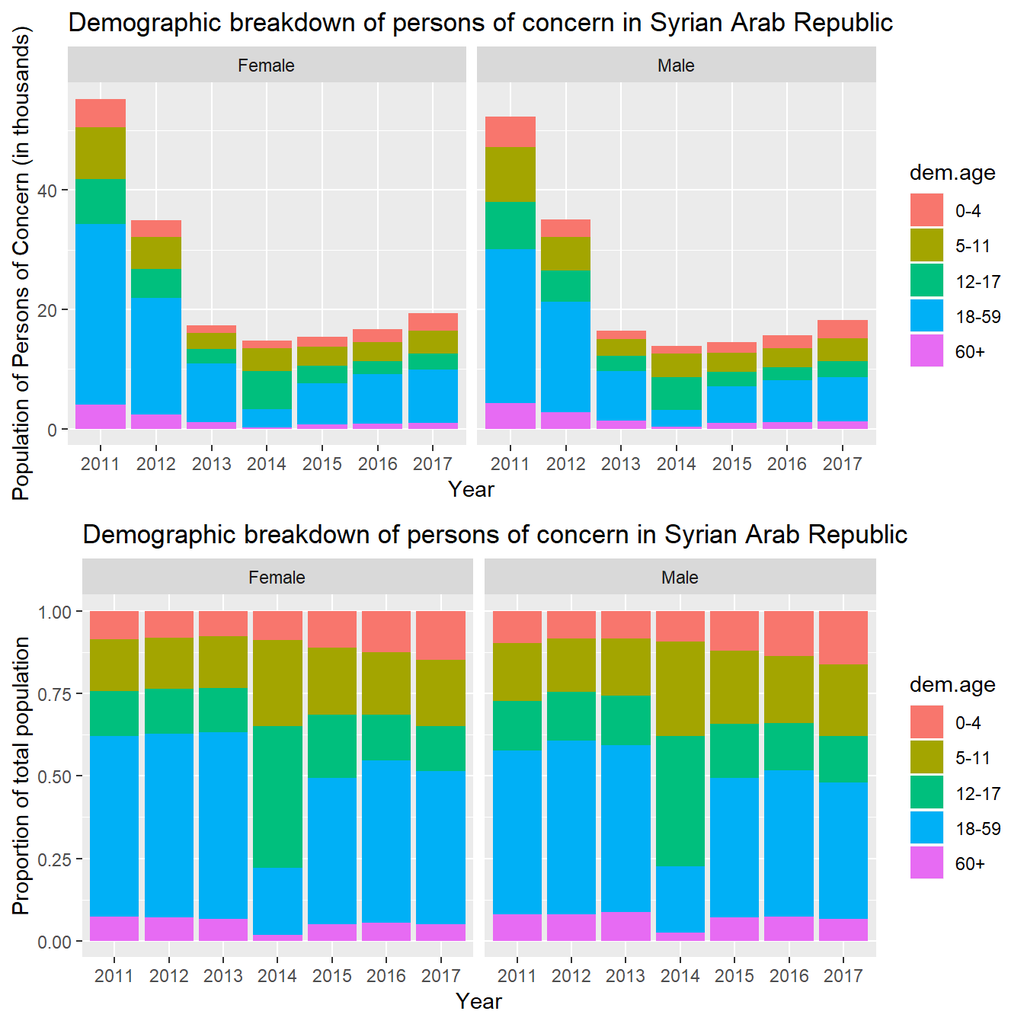

```r
### Syria
# Cleaning for Syria
dem_syria <- dem_long %>%
  filter(Country == 'Syrian Arab Rep.') %>%
  filter(Year >= 2011 & Year <= 2017) %>%
  filter(dem.sex %in% c("Female","Male")) %>%
  group_by(Country, Year, dem.sex, dem.age) %>%
  summarise(number = sum(number))

# The age 5-17 category was not used in tracking persons of concern from South Sudan
dem_syria<-dem_syria[!(dem_syria$dem.age =="5-17"),]

# Reordering the factor categories
dem_syria$dem.age <- factor(dem_syria$dem.age, levels = c("0-4", "5-11", "12-17", "18-59", "60+"))

# Failed bar plot
syria_stack <- ggplot(dem_syria, aes(x = factor(Year), y = number / 1000)) +
  geom_bar(aes(fill = dem.age),stat = "identity", position = "stack") +
  facet_wrap(.~dem.sex) +
  xlab('Year') +
  ylab('Population of Persons of Concern (in thousands)') +
  ggtitle('Demographic breakdown of persons of concern in Syrian Arab Republic')

# Failed bar plot (proportions)
syria_fill <- ggplot(dem_syria, aes(x = factor(Year), y = number / 1000)) +
  geom_bar(aes(fill = dem.age),stat = "identity", position = "fill") +
  facet_wrap(.~dem.sex) +
  xlab('Year') +
  ylab('Proportion of total population') +
  ggtitle('Demographic breakdown of persons of concern in Syrian Arab Republic')

grid.arrange(syria_stack, syria_fill)
```

As seen from the above chart, there appears to be a sharp dip in the demographic data recorded for Syria from 2011 to 2012, and 2012 to 2013. However, from news sources and the timeseries data, we know that that is not true. First inspection of the data also tells us that the local regions at which data is collected year after year are mostly unique, which probably resulted in a lapse in data quality.

## 5 Executive Summary

Our project sought to characterize refugee movement over the past decade. This was implemented by performing exploratory data analysis using the UNHCR data. The database currently contains data about UNHCR’s populations of concern from the year 1951 up to 2017, which includes the following 6 categories: Refugees, Asylum Seekers, Internally displaced persons, returned refugees, returned IDPs, stateless persons and others of concern. This data was used to investigate different aspects of these populations: their general composition by location of residence or origin, their status, their numbers over time, and so on.

The primary questions of interest were, Where are refugees mostly originating from and what kind of events occurred to make them leave? Which are the countries taking in the most refugees, and why? Which demographic segments of the population are affected by these crisis? This was executed by subsetting the data into different time periods and exploring the refugee movement for the different countries using time series analysis.

The key findings from our project are: the top 5 countries with the highest refugee populations, the causes for this displacement of people, and the countries to which these people have resettled. The first and last point has been concisely summarized in our alluvial diagram that represents the flow of refugees from origin country to their country of resettlement.

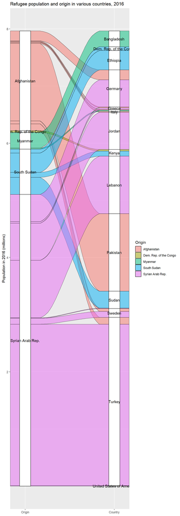

```r
alluvial
```

The demographics dataset was used to identify the different age groups of refugees from the 5 selected countries. There were obvious gaps in the dataset for the most part, revealing inconsistencies in data collection methods and locations. Out of these 5 countries, the demographic data for South Sudan was the most complete and thus the graph is included below. The first chart shows the demographic breakdown of persons of concern in South Sudan, by absolute value, while the second chart shows the proportion in each demographic category, with the data for all years normalized to the full height of the chart. It reveals a steady increase in absolute numbers for the persons of concern population, while the proportion in each age category remains largely the same. The last graph is a variable width bar chart, in which the chart area represents the total number in that category. This was done since the categories were of different sizes in the demographic data. This last chart reveals the fact that woman and their children are disproportionately affected by the crisis.

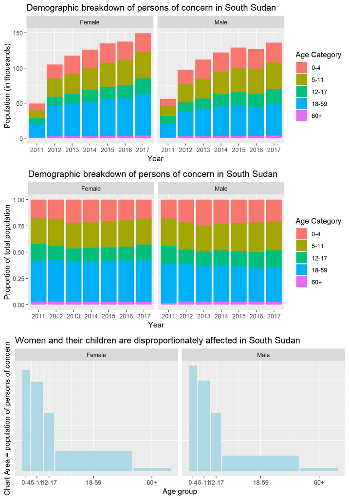

```r
grid.arrange(sudan_stack, sudan_fill, sudan_variable)
```

Our interactive component includes both a map and line chart that summarises the persons of concern population for each origin country and the countries they relocated to. Our main conclusion from that visualization, thanks to the spatial representation of the countries, was that the majority of the persons of concern relocated to neighboring countries. Countries that are neighbors to conflicts and violence are therefore bearing the brunt of the refugee inflow from those events.

# 6 Interactive Component

## 6.1 Design

For our interactive component, we wanted to design a graph that captured the crux of our analysis - the events that led to the current expansion of refugee populations while also tracking their movements around the world.

### 6.1.1 Layout

The interactive component consists of two graphs which are arranged one above the other. The graph on top is a line chart which tracks the refugee population for a particular countries of interest across a period of just over 25 years. The bottom graph is a geographic heat map representing a snapshot of the movement of these populations around the world.

### 6.1.2 Interactivity

The buttons at the top of the chart are used to select the particular country that you wish to view trends for. Selecting the buttons also displays polygons which highlight historical events that explain the existing trends in the data. The default display being that for Syria. Hovering over the line chart area filters the below heat map by year according to the position of the mouse.

## 6.2 Usage Instructions

To maximize the utility of the interative graph, please follow the following instructions. They will also highlight the gaps and probable questions that may arise while using it.

### 6.2.1 Buttons

To change from one country of interest to another, click on the button present on the top of the graph. Clicking these buttons also triggers a highlight from the start date to the end date of events we have recorded during the analysis. Please wait for the initial transition on loading the page to complete before you click a button.

### 6.2.2 Date Filter

We employed a date filter on the geographical heat map to allow the viewing of any desired snapshot of refugee movement within the displayed date range. Hover your mouse over a clear section of the line graph background to filter by the required year. Filters are applied based on the position of the mouse relative to the x-axis of the line graph. Note: Hovering over the displayed polygon will not work, you will have to move to a non plotted portion of the graph.

## 6.3 Technical Execution

A mixture of R, D3 and Javascript were employed to execute the interactive visualization.

### 6.3.1 Line Chart

The line chart was executed in D3 by binding the relevant data stored in csv files to the DOM elements to construct the graph. Transitions were applied for a aesthetic movement of the line for different regions.

### 6.3.2 Geographic Heat Map

The maps were plotted in R using the choroplethr packages and subsequently exported to images. Each corresponded to a snapshot of a particular year and country. These were rendered in html using d3 and the interactive components were constructed using a mixture of Javascript and D3.

### 6.3.3 Future Scope

The clarity and aesthetics of this interactive visualization could be enhanced by using available d3 libraries such as topoJSON in order to construct the spatial map representation. There are a much wider range of transitions and perspectives that can be achieved using such a library.

## 6.4 Link to the visualization

https://tinyurl.com/edav-interactive

## 7 Conclusion

Key challenges that we faced throughout the course of this project are:

- Identifying meaningful subsets of data: The data set was widespread from the years of 1950 to 2017 for 230 countries. Spotting meaningful trends in this large dataset was a time consuming task as it required lots of data cleaning and subsetting.
- Missing data: The demographics data had several missing values and was inconsistent in its parameters. The data was collected at different locations which lead to data redundancy.
- Navigating confidential data points: There were several situations where data was being kept confidential in order to protect the individuals.These confidential data points were a hinderence during exploration.
- Extracting mappable coordinates for spatial representations: The countries present in the dataset were not concurrent with the countries used in the Choroplethr function, hence they had to be mapped externally using Excel joins.

Future Directions with this project:

- Using an interactive SVG map components like TopoJSON to represent the dynamic flow of refugees, instead of static representations.
- Analyses of political landscape obstructing refugee flows, most refugees tend to settle in neighbouring countries that are closer to home although those countries are not the best choice for them. There could be some underlying reasons to this behaviour.

Some valuables lessons learned:

- Data wrangling took up almost 70% of the time and work. It is very important to start this phase much earlier. In order to extract meaningful insights from the data, we need to thoroughly understand what it represents.
- Data consistency/quality is extremely important for exploratory data analysis.
- We have also expanded our geographical knowledge profusely, thanks to the manual mapping of chroplethR Country values!

Thank you for reading!